# I. Dinámicas de innovación tecnológica.

# Objetivo de la sección.

Al final de esta sección el participante podrá:

- Conocer los conceptos básicos acerca de tecnología, innovación y creatividad.
- Identificar los tipos de innovación que existen.
- Reconocer el papel primordial del conocimiento ante la innovación tecnológica.
- Formar criterios para priorizar proyectos de innovación.
- Entender el reto de comunicar efectivamente una propuesta de innovación.
- Conocer los componentes del proceso de innovación.

# Definiciones preliminares.

## Tecnología.

**"*Grado de obtención del valor potencial de un recurso, mediante conocimientos y habilidades relativas al saber hacer y su combinación con recursos materiales, de manera sistemática, repetible y reproducible.*"**

-NMX-GT-001-IMNC-2007

## Innovación.

**"*Proceso dirigido a un mercado bajo un enfoque de negocio que detecta oportunidades y capacidades organizacionales para generar productos, procesos y servicios, novedosos aceptados por los consumidores.*"**

-NMX-GT-001-IMNC-2007

## Innovación tecnológica.

**"*Proceso que conjuga una oportunidad de mercado con una necesidad y/o una invención tecnológica, que tiene por objetivo la producción, comercialización y explotación de un nuevo proceso, producto, actividad comercial, modelo de negocio, modelo de logística o servicio al cliente.* "**

-NMX-GT-001-IMNC-2007

# Aclaraciones.

- Ciencia y tecnología NO son los mismo.
- Creatividad e innovación NO son lo mismo.
- Los conceptos también aplican a gobiernos y ONG.

# Fuerzas que impulsan a la innovación.

- "Commoditization".
- La revolución digital.
- Los medios sociales.
- Globalización.
- La creciente turbulencia del entorno mundial.
- Aceleración.

**Fuente:**

Morris, L. (2011). The Innovation Master Plan: The Ceo's Guide to Innovation. USA. Innovation Academy.

https://innovationmanagement.se/wp-content/uploads/2011/08/Innovation-Master-Plan_Chapter-2.pdf

## Actividad en el aula (i).

- Identifique aquellos factores que impulsen a la innovación en su organización y clasifíquelos conforme al listado previo.
- ¿Hay algún factor que no pueda ser catalogado correctamente?

# Tipos de innovación.

- Modelo de utilidad.
- Conexiones y contactos (network).
- Estructura de la organización.
- Procesos.
- Rendimiento del producto.

# Tipos de innovación (continuación).

- Sistema de producción.
- Servicios.
- Canales.
- Marca.
- Compromiso con el cliente.

**Fuente:**

Keeley, L., Walters, H., et al. (2013). Ten Types of Innovation: The Discipline of Building Breakthroughs. Hoboken, N.J.: John Wiley & Sons, Inc.

https://www.doblin.com/ten-types

## Actividad en el aula (ii).

A partir de la hoja de cálculo *matriz_de_tipos_de_innovacion.ods* realice lo siguiente:

- Identifique una empresa, producto o servicio sobre el que se pueda innovar.
- Realice 5 propuestas de innovación y cambie el color de la celda dentro de la matriz en la columna correspondiente al tipo de innovación de la que se trate.

# Inteligencia de innovación.

La toma de decisiones no puede basarse en adivinación ni en "corazonadas", y aún cuando ciertos líderes cuentan con una gran sensibilidad e intuición, esto no es suficiente para justificar el despliegue de estrategias a largo plazo.

Las decisiones en materia de innovación deben de estar respaldadas por datos que definan y delimiten aspectos críticos de la organización.

## Las iniciativas de innovación implican:

- Conocimiento del negocio.
- Conocimiento de los procesos.
- Conocimiento del mercado.
- Conocimiento tecnológico.

## Información para decidir.

En cualquier nivel, el uso de información veraz, completa y oportuna permite tomar decisiones razonadas.

Incluso con suficiente información histórica es posible realizar predicciones por medio de técnicas estadísticas y de análisis de datos.

## Datos -> Información -> Conocimiento.

La innovación tecnológica carecería de sentido si no se contara con información que la respaldara. Los datos, la información y el conocimiento son tema central de esta asignatura.

### El conocimiento de la organización.

La experiencia de las personas dentro de una organización es la más pura, pero a la vez la más escurridiza fuente de conocimientos.

Es común que existan personas con conocimientos claves en las organizaciones, pero la fragilidad de la permanencia de este conocimiento es un constante riesgo que debe ser mitigado mediante la creación de bases de conocimiento y la comunicación.

### El oceáno de datos.

En el otro extremo se encuentran los datos del negocio, de los procesos y de los mercados. Cualquier fenómeno o actividad que se pueda medir o incluso percibir es susceptible de convertirse en un dato y estos datos deben de ser procesados y analizados para poder ser útiles.

# Actividad en el aula (iii).

- Identifique al menos 5 fuentes de datos internos o externos de su organización.
- Indique si esa información pertenece al negocio, a los procesos o al mercado de la organización.
- Diga cómo podría aprovechar esos datos.
- Identifique a 2 personas en su organización que tengan conocimientos clave y cómo podría lograr que estas personas los compartieran con la organización.
- Enumere las herramientas que conozca para obtener, almacenar, procesar, analizar y comunicar datos.

# Selección de proyectos de innovación.

Los procesos de innovación consumen diversos tipos de recursos tanto de las personas y como de las organizaciones.

Poder decidir (apostar) entre todas las opciones por aquellas que logren un equilibrio entre su impacto y su costo es tan importante como las ideas mismas.

## Innovación táctica.

Las organizaciones que no han adoptado a la innovación como parte de sus procesos se encuentran expuestas a un estado de inercia en el que la innovación sólo se da:

- Cuando una persona dentro de la organización descubre e impulsa una innovación (fenómeno Eureka).
- Cuando los factores de cambio obligan a la organización a evolucionar.

En este caso, la innovación es aleatoria y reactiva.

No existe un proceso de innovación.

## Innovación estratégica.

Las organizaciones que incluyen a la innovación en sus procesos y organigrama son capaces de:

- Crear estructuras organizacionales que fomenten la innovación, tales como las áreas de investigación, desarrollo e innovación (I+D+I).
- Contar con información y conocimientos sobre su negocio, procesos y mercado que les permiten actuar de forma anticpada.
- Forjar alianzas con otros actores en condiciones favorables para aprovechar la innovación.
- Contar con un aservo de capital intelectual.
- Estar mejor preparadas para afrontar entornos adversos.

## Propiedad industrial.

La innovación es susceptible de tener un valor económico intrínseco.

Las ideas, los planes de negocios, la descripción de los procesos, las imágenes, los cursos y los documentos técnicos, aún cuando no tengan aplicación inmediata, pueden ser activos intangibles de las organizaciones.

https://www.gob.mx/se/articulos/la-propiedad-industrial-en-mexico

## Actividad en el aula (iv).

Se identificarán innovaciones que sean susceptibles de ser patentadas como innovaciones o registradas como obras.

¿Cómo se valúan los activos intangibles?

# El proceso de innovación tecnológica.

La NMX-GT-003-IMNC-2009 define el proceso de gestión tecnológica con el siguiente diagrama.

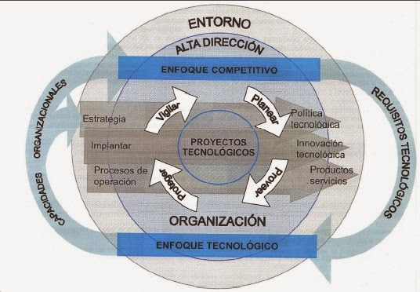

## Etapas del ciclo:

- Vigilar. Implica ser sensible al entorno y contar con una estrategia de inteligencia de innovación.
- Planear. Implica conocer la realidad de la organización y a partir de la información, diseñar estrategias.
- Proveer. Implica obtener, asignar y facilitar recursos en aras del desarrollo de innovaciones.
- Proteger. Implica realizar las acciones necesarias para salvaguardar los activos intangibles resultantes del proceso.

## El Manual de Gestión Tecnológica.

CamBioTec, A.C., auspiciado por Conacyt-FINNOVA ha publicado el [Manual de Gestión Tecnológica para PyMES mexicanas](http://www.cambiotec.org.mx/manualdegestiontecnologica/), el cual se basa en las NMX de gestion tecnológica y las extiende para su aplicación en organizaciones mexicanas.

http://cambiotec.org.mx/manualdegestiontecnologica/archivos/MGT.pdf

# Comunicación con los implicados e interesados (stakeholders).

La capacidad de transmitir una idea a personas fuera del ámbito cultural y de interés de un individuo se vuelve un facilitador para la adopción de la innovación.

La comunicación se puede dar por medios formales tales como:

- Juntas de trabajo.
- Sesiones informativas.
- Reportes.
- Correos electrónicos.
- Conferencias y seminarios.

Sin embargo, en muchos casos los mensajes no llegan o no impactan.

Poder comunicar una idea de forma rápida y efectiva ante una persona con capacidad ejecutiva es una habilidad que puede definir el futuro de un negocio.

## Actividad en el aula (v).

- Formar equipos de 3 personas.
- identificar una idea innovadora.
- Realizar un elevator pitch sobre dicha idea.

# Proyecto en equipo.

- Formar equipos de 3 a 4 personas.
- Ecoger uno de los siguientes negocios:
  - Amazon Web Services.
  - Rappi.
  - Mercado Libre.
  - Platzi.
- Hacer un análisis histórico del negocio y desarrollar un reporte ejecutivo al respecto (máximo 2 cuartillas).
- Identificar en la matriz de innovación, los impactos del negocio seleccionado.
- Identificar a 3 actores que compitan directamente de cada negocio y su diferencia en la propuesta de valor.
- Proponer al menos 3 posibles ideas para mejorar o extender el negocio.